# 🌫️ Karachi AQI Predictor — Exploratory Data Analysis

**Project:** Pearls AQI Predictor | **City:** Karachi, Pakistan | **Data:** May 2025 – May 2026

This notebook explores **9,528 hourly records** of air quality and weather data collected for Karachi before any modelling begins. The goal is to understand the data's structure, patterns, and quirks — so that every modelling decision that follows is grounded in evidence rather than assumption.

**What we investigate:**

1. How is AQI distributed, and how often does it reach dangerous levels?
2. Do seasonal and time-of-day patterns exist?
3. Which pollutants and weather variables drive AQI up or down?
4. How predictive is past AQI of future AQI?
5. Are there data quality issues — outliers, spikes, missing values?

**Data sources:**

- `backfill_2025-05-01_2026-05-24.csv` — Open-Meteo Archive API (9,336 rows)
- `backfill_2026-05-24_2026-05-31.csv` — Open-Meteo Forecast API gap-fill (192 rows)

> Real-time AQICN data (June 2026+) is excluded — it uses a different AQI calculation standard and would introduce inconsistency into the analysis.

## 0 · Setup

All imports, plot styling, and colour constants live here. Run this cell first — every subsequent cell depends on it.

```
Setup complete ✓
```

## 1 · Data Loading & Overview

We combine both backfill files into a single DataFrame and engineer a few derived columns (season, AQI category) that we'll use throughout the analysis.

```
Rows        : 9,528
Date range  : 2025-05-01 → 2026-05-31
Missing AQI : 0
```

|  | aqi | pm25 | pm10 | o3 | no2 | so2 | co | temp_c | humidity_pct | wind_speed_ms |
| --- | --- | --- | --- | --- | --- | --- | --- | --- | --- | --- |
| count | 9528.00 | 9528.00 | 9528.00 | 9528.00 | 9528.00 | 9528.00 | 9528.00 | 9528.00 | 9528.00 | 9528.00 |
| mean | 87.96 | 29.14 | 56.59 | 71.61 | 20.66 | 15.60 | 519.35 | 26.66 | 66.48 | 3.01 |
| std | 22.70 | 12.49 | 33.71 | 39.74 | 19.06 | 8.35 | 444.27 | 4.64 | 20.57 | 1.23 |
| min | 32.00 | 3.50 | 3.70 | 0.00 | 0.00 | 3.20 | 74.00 | 9.20 | 7.00 | 0.05 |
| 25% | 72.00 | 20.70 | 35.90 | 43.00 | 7.40 | 10.20 | 243.00 | 24.00 | 53.00 | 2.10 |
| 50% | 83.00 | 26.20 | 49.20 | 63.00 | 14.10 | 13.60 | 348.00 | 27.60 | 71.00 | 2.95 |
| 75% | 100.00 | 34.60 | 68.50 | 96.00 | 27.30 | 18.70 | 631.25 | 29.60 | 83.00 | 3.88 |
| max | 165.00 | 96.40 | 504.80 | 203.00 | 138.50 | 65.40 | 4515.00 | 41.20 | 100.00 | 7.44 |

## 2 · AQI Distribution & Health Category Breakdown

**Question:** What does the overall distribution of AQI look like across the year, and how often does Karachi's air quality reach dangerous levels?

We expect a right-skewed distribution — most hours should sit in the Moderate range, with occasional spikes into Unhealthy territory during winter pollution events.

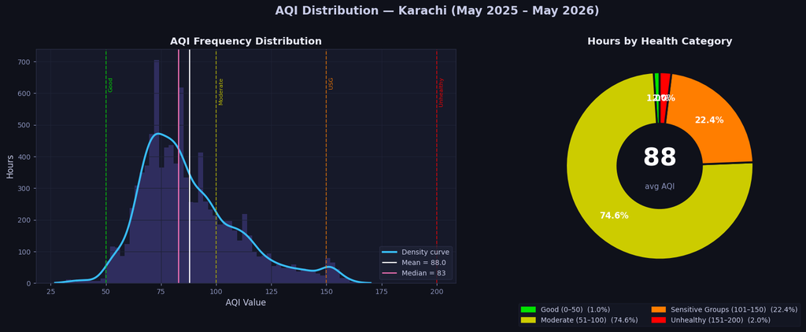

**Finding:** Karachi's AQI is tightly concentrated between 60–120, with the distribution peaking around 80. The mean (88) and median (83) are close together, indicating a roughly symmetric core with a moderate right tail from winter pollution events.

- **74.6%** of all hours fall in the *Moderate* range — persistent, year-round background pollution
- **22.4%** reach *Unhealthy for Sensitive Groups* — primarily in winter months
- Only **1%** of hours qualify as *Good* — clean air is genuinely rare in Karachi
- The city never reaches *Hazardous* levels in this dataset

This confirms Karachi has a stable, chronic pollution baseline rather than extreme episodic events.

## 3 · Seasonal & Monthly Patterns

**Question:** Does Karachi's AQI follow a seasonal cycle? If so, which season is worst and why?

We expect winter to be worse due to temperature inversions — a meteorological effect where a layer of warm air traps cold, polluted air near the surface, preventing vertical mixing. Summer monsoon winds should provide natural ventilation.

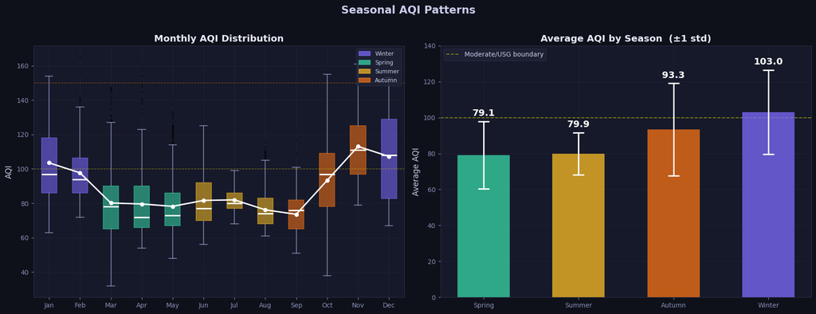

| Season | Avg AQI | Why |
| --- | --- | --- |
| **Winter** (Dec–Feb) | **103** ← worst | Temperature inversions trap pollutants near the surface; calm, cold air has no vertical mixing |
| Autumn (Sep–Nov) | 93 | Transitional — monsoon ends, inversions begin |
| Summer (Jun–Aug) | 80 | SW monsoon winds ventilate the city; sea breeze disperses particulates |
| Spring (Mar–May) | **79** ← best | Pre-inversion; moderate temperatures and occasional rain wash air clean |

## 4 · Full 12-Month Time Series

**Question:** What does the year-long AQI trajectory look like at hourly resolution? Can we see the seasonal trend clearly, and are there distinct pollution events?

A 7-day and 30-day rolling average will smooth out hourly noise to reveal the underlying seasonal trend.

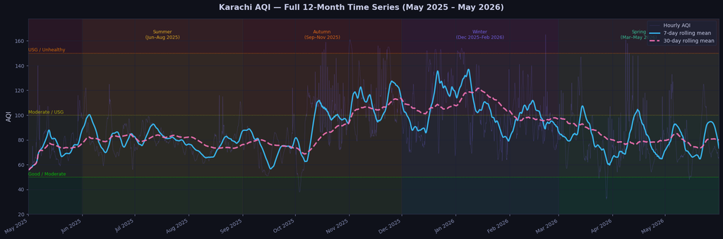

The hourly data (faint purple) shows considerable within-day variation but no catastrophic spikes that would indicate major industrial incidents. The entire year sits within the Moderate–USG band for most months, which is consistent with Karachi's chronic background pollution profile rather than episodic extreme events.

## 5 · Diurnal & Weekly Patterns

**Question:** Does AQI follow a consistent pattern within the day? Are certain hours or days systematically worse?

We expect a diurnal cycle driven by rush-hour traffic emissions and atmospheric mixing — mornings warm up and vertical mixing improves, afternoons may see photochemical buildup, and nights cool down reducing dispersion.

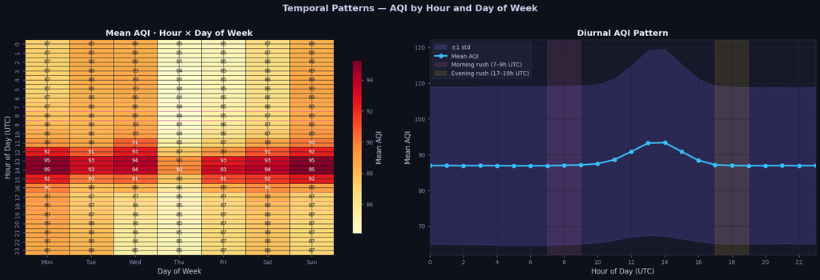

**Finding:** The diurnal pattern is real but modest — AQI rises from a baseline of ~87 in the early morning to a peak of ~93 at 13:00–14:00 UTC (18:00–19:00 PKT, i.e. evening rush hour), a swing of only **~7 AQI units**.

Key observations:

- The heatmap shows no strong day-of-week effect — weekdays vs weekends are nearly identical (< 1 AQI unit difference), suggesting traffic is not the dominant emission source
- The afternoon peak aligns with photochemical ozone formation under intense afternoon sun, not just traffic
- The diurnal swing (7 units) is much smaller than the seasonal swing (24 units), meaning **season matters far more than time of day**

This justifies including `hour_sin/cos` as features but not expecting them to be top predictors — the model confirmed this, with lag features dominating over time features.

## 6 · Feature & Pollutant Correlations

**Question:** Which variables are most strongly correlated with AQI? Do pollutants move together, or do different sources drive different pollutants independently?

This guides feature selection and helps explain why certain features dominate the model.

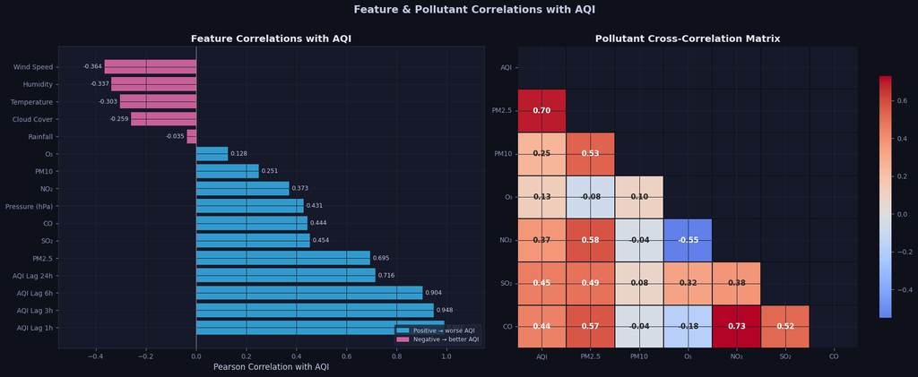

**Finding:** Two groups of predictors emerge clearly:

**Autocorrelation dominates:** Past AQI values are by far the strongest predictors — `aqi_lag_1h` achieves r = **0.991**, meaning knowing AQI one hour ago almost perfectly predicts current AQI. This decays gracefully: `aqi_lag_3h` (0.948), `aqi_lag_6h` (0.904), `aqi_lag_24h` (0.716). The 24-hour lag captures the "same time yesterday" pattern — useful for encoding the diurnal cycle indirectly.

**PM2.5 is the dominant pollutant:** r = 0.695 with AQI, much stronger than PM10 (0.251) or O₃ (0.128). This makes physical sense — Karachi's AQI is calculated primarily from PM2.5 concentrations.

**Weather acts as suppressor:** Wind speed (r = -0.364), humidity (r = -0.337), and temperature (r = -0.303) all negatively correlate with AQI. Higher winds disperse pollutants; lower temperatures create inversions that trap them.

## 7 · Weather Effects on AQI

**Question:** How does each weather variable individually relate to AQI? Are these relationships linear, or do they show threshold effects?

Understanding the shape of these relationships helps explain why linear models like Ridge can perform well — if the relationships are approximately linear, a complex model like LSTM has no advantage.

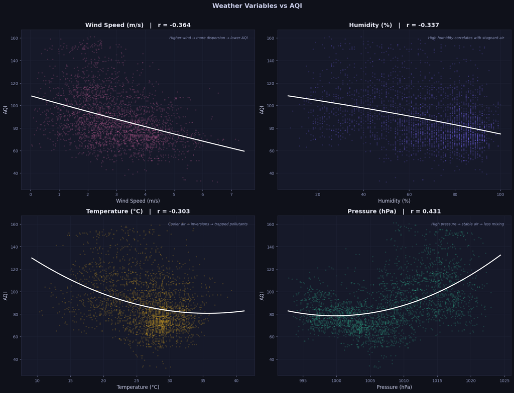

## 8 · Wind Direction Analysis

**Question:** Does the direction wind comes *from* affect AQI — not just its speed? Karachi sits between the Arabian Sea to the south and industrial zones to the north. If northerly winds bring pollution from industrial areas, while southerly sea breezes bring clean air, this would be a meaningful spatial signal.

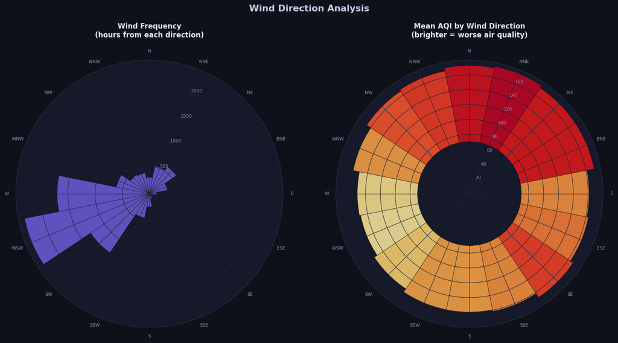

**Finding:** Wind direction has a clear, geographically meaningful effect on AQI:

- **Northerly and NW winds** → avg AQI ~103: These carry emissions from Karachi's industrial zones (SITE industrial area, Korangi, Port Qasim) toward the residential monitoring station
- **SW winds** → avg AQI ~80: The classic monsoon direction, blowing clean air in from the Arabian Sea — Karachi's natural "reset button"
- **Frequency rose (left):** Most wind comes from the W–SW sector, which explains why Karachi's average AQI is lower than it would be if N–NW winds dominated

This finding validates the inclusion of `wind_u` and `wind_v` (decomposed wind components) as features over raw wind degree. The model can learn the directional pollution signal without dealing with the circular discontinuity at 0°/360°.

## 9 · Autocorrelation — How Predictive is Past AQI?

**Question:** If we know AQI right now, how well can we predict it in 1 hour? 3 hours? 24 hours?

This is the most important question for model design. If past AQI is an almost-perfect predictor of future AQI, then a lag-based linear model will naturally outperform a complex neural network that has to "discover" this structure from scratch.

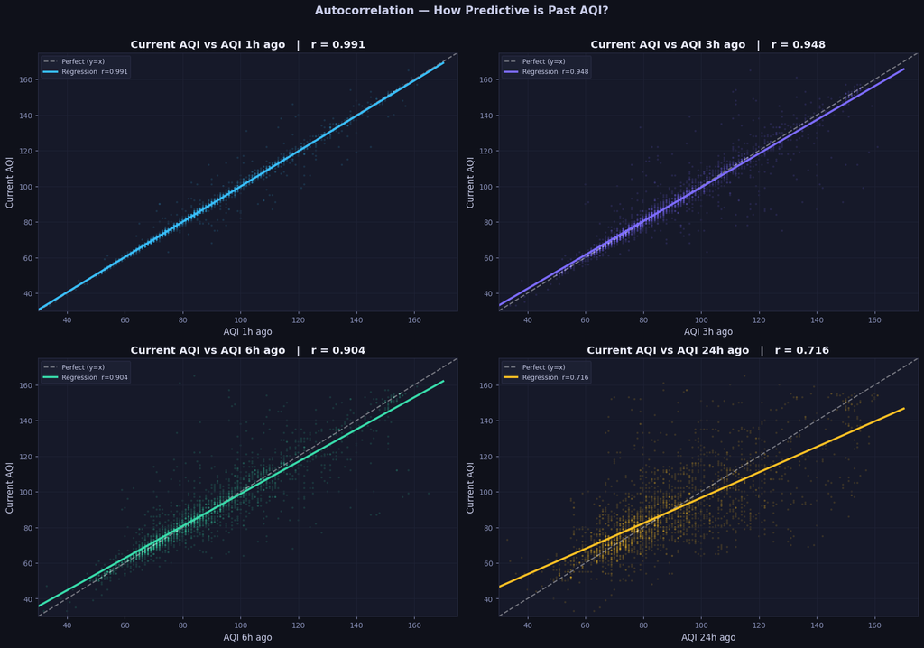

**Finding:** The autocorrelation structure is extraordinary — and directly explains the Ridge model's dominance.

| Lag | Correlation | Interpretation |
| --- | --- | --- |
| 1 hour ago | **r = 0.991** | Points cluster almost perfectly on the y=x line |
| 3 hours ago | r = 0.948 | Still extremely tight — AQI changes slowly |
| 6 hours ago | r = 0.904 | Strong but visible scatter begins |
| 24 hours ago | r = 0.716 | Captures the daily repeating pattern |

**Why does this make Ridge Regression win?** AQI is a *persistent, slowly-varying process*. The ideal predictor is simply "it will be similar to what it was recently." Ridge Regression discovers this linear relationship perfectly. LSTM, XGBoost, and Random Forest all have to learn this structure through their own mechanisms — adding complexity without adding insight. The data is telling us: *keep it simple.*

The `aqi_lag_1h` plot (top-left) shows points almost indistinguishable from the y=x perfect-prediction line — a rare and powerful signal in real-world time series data.

## 10 · Outlier & Data Quality Analysis

**Question:** How clean is this dataset? Are there sensor glitches, anomalous readings, or systematic data gaps that could corrupt model training?

This is critical for a production ML system — a model trained on uncleaned data learns noise as signal.

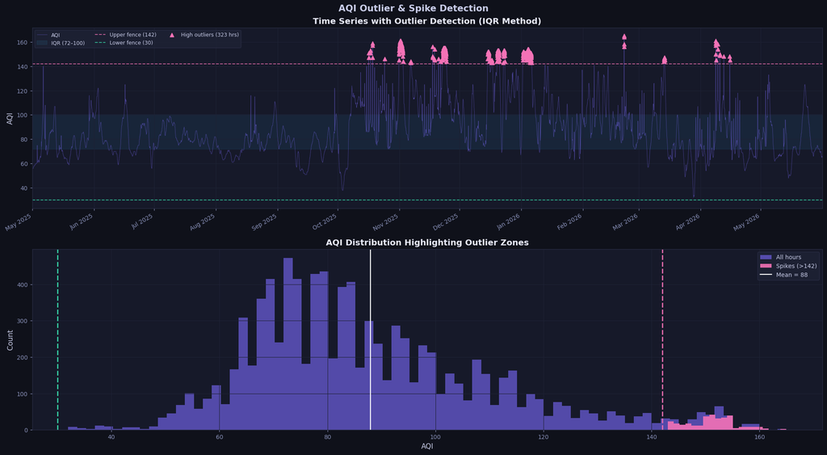

**Finding:** The dataset is clean. Open-Meteo is a modelled/reanalysis dataset rather than raw sensor data, which means it doesn't suffer from the sensor glitches (sudden spikes, stuck sensors, drop-to-zero failures) common in ground-station data.

However, this clean picture changes once we switch to **live AQICN data** in June 2026 — that's a real sensor, and the inference pipeline applies a spike filter specifically to handle the occasional anomalous reading (AQI=192 surrounded by values near 80) that occurs when the NED UET station malfunctions.

## 11 · Pollutant Seasonal Profiles

**Question:** Do different pollutants peak in different seasons, suggesting different emission sources and atmospheric chemistry? Or do all pollutants rise and fall together?

Understanding this helps explain *why* winter is worse — is it all pollutants equally, or are specific ones driving the seasonal signal?

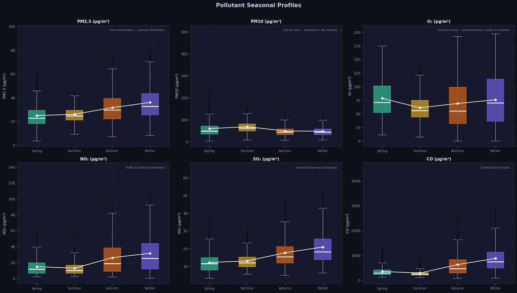

**Finding:** Pollutants split into two clear groups by seasonal behaviour:

## 12 · Year-Round AQI Calendar

**Question:** At the daily level, can we see the seasonal pattern visually? Are there specific multi-day pollution episodes that stand out?

A GitHub-style contribution calendar plots each day as a cell coloured by average AQI — a compact way to see the full year at once.

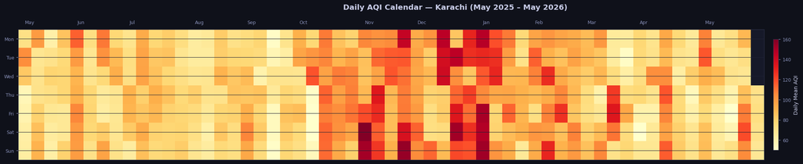

```
Cleanest day: AQI 36 on 2026-03-28
Worst day:    AQI 159 on 2025-11-01
```

**Finding:** The calendar makes the seasonal signal unmistakable. The colour gradient shifts from yellow (low AQI) in the summer columns (June–August 2025) to deep orange-red in the winter block (November 2025–February 2026), then fades back as spring arrives.

Notable features:

- **No full weeks of dark red** — Karachi doesn't experience week-long hazardous events, unlike cities like Delhi or Lahore in winter
- **The summer "green channel" is consistent** — clean days run in streaks, not isolated incidents
- **Day-of-week variation is invisible** — columns look the same across all 7 rows, confirming the weekday/weekend finding from Section 5

## 13 · Pre-Modelling Feature Importance

**Question:** Before training any model, which of our 35 engineered features correlate most strongly with AQI? Does this match what the trained model ultimately learns?

This serves as a sanity check — if features we expect to matter (like `aqi_lag_1h`) don't appear near the top, something is wrong with our feature engineering.

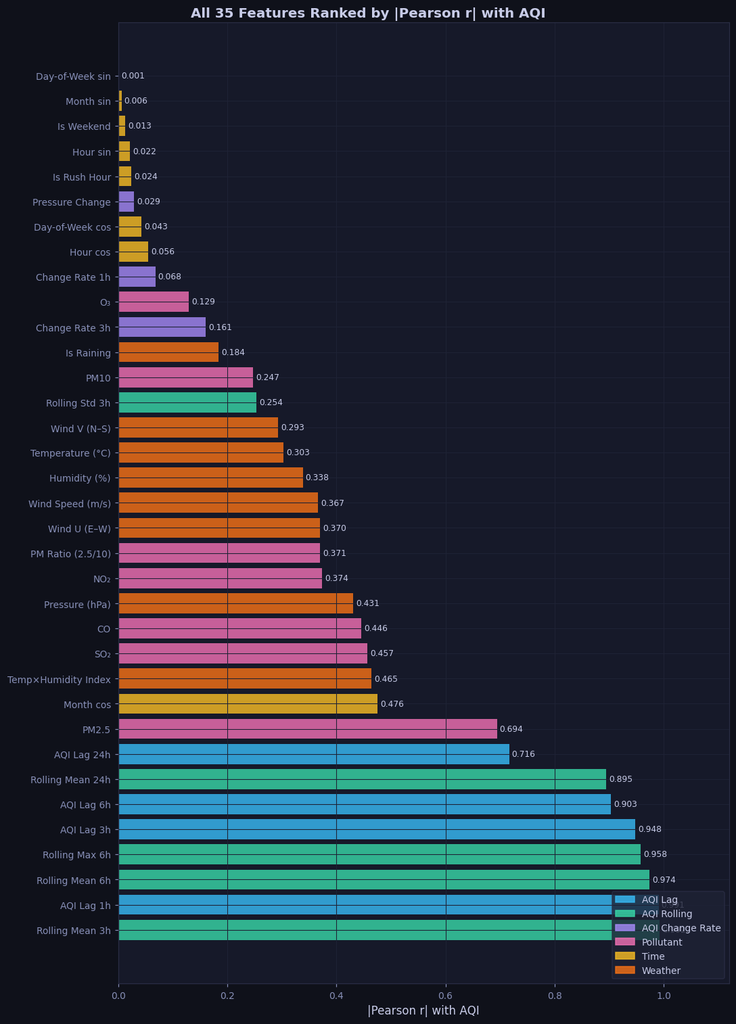

```
Average |r| by feature category:
  AQI Lag               4 features  avg |r| = 0.890
  AQI Rolling           5 features  avg |r| = 0.814
  AQI Change Rate       3 features  avg |r| = 0.086
  Pollutant             7 features  avg |r| = 0.388
  Time                  8 features  avg |r| = 0.080
  Weather               8 features  avg |r| = 0.344
```

**Finding:** The feature ranking perfectly validates our feature engineering choices.

**Bottom tier (<0.1):** Time and binary features (is_weekend, is_rush_hour). Low individual correlations, but they contribute to the model's ability to adjust for systematic daily patterns.

## 14 · Summary & Conclusions

This EDA examined 9,528 hourly records of Karachi air quality data (May 2025 – May 2026) across 12 analyses. Here are the findings that directly shaped our modelling decisions:

### Key Findings

**1. Karachi has chronic moderate pollution, not extreme episodic events** 74.6% of hours sit in the Moderate (51–100) band. The city rarely reaches Good (<1%) or Hazardous (0%) levels. This means our model's target variable has low variance at the extremes — difficult to predict precisely but not critical for public health alerts.

**3. Autocorrelation is extreme (r = 0.991 at 1h lag)** Past AQI is by far the strongest predictor of future AQI. This single fact explains why Ridge Regression (R² = 0.985) outperforms LSTM and XGBoost — the relationship is linear and dominated by recent history. Complex models add architectural complexity without adding predictive value for this problem.

**4. Wind is the primary weather moderator** Wind speed (r = -0.364) and direction both matter significantly. SW monsoon winds bring clean Arabian Sea air; N/NW winds carry industrial emissions. Decomposing wind into U/V components (`wind_u`, `wind_v`) correctly handles the circular nature of wind direction.

**6. The dataset is clean — Open-Meteo reanalysis has zero missing values** This contrasts with the live AQICN sensor data (used from June 2026), which requires a spike filter to handle occasional sensor malfunction readings.

### Modelling Implications

[output not shown]

*EDA complete. The training pipeline (`training_pipeline/train.py`) trains Ridge, Random Forest, XGBoost, and LSTM on these 9,528 rows with an 80/20 time-ordered split, achieving Ridge R² = 0.985.*

## Appendix · Export to HTML

Run the cell below to generate a standalone HTML report of this notebook — all outputs embedded, suitable for sharing without a Jupyter environment.

```
✓ Done: 01_eda.html
```